# HW2

### Jiayou’s Graph

I fell like the graph personally when I hover on the bubbles, it tells me exact how many cases in that bubble. However, there are two things that really makes trouble when viewing. It is not that bad for me, especially I think I have no idea how to redo it for now. Technically, it is very interesting to me.

Advantages:

1. No information is lost, we see the graph and just hover on the bubbles, we can get all the information we need, which is cool to be a graph with full information.
2. The decent usage of hue, identifying the year of vaccince clearly, as well as the shape(scale) of the bubbles, indicating the cases’ size.

Disadvantages:

1. The overlapping of bubbles are severe prblems preventing me to see the patterns clearly, I may group the problem as bad usage of luminance as the luminance in the picture actually means nothing, but it is a bit misleading to me.
2. The size of the bubbles give us the information, if it could be something like lines, or violin plot, it could say more spaces for each year, which may make the graph no overlapping.
3. The size of the graph is too large, if we could shrink the length, it may be better for viewing.
4. If the graph is horizontally rather than vertically, it may be better for me.

### Graph 1

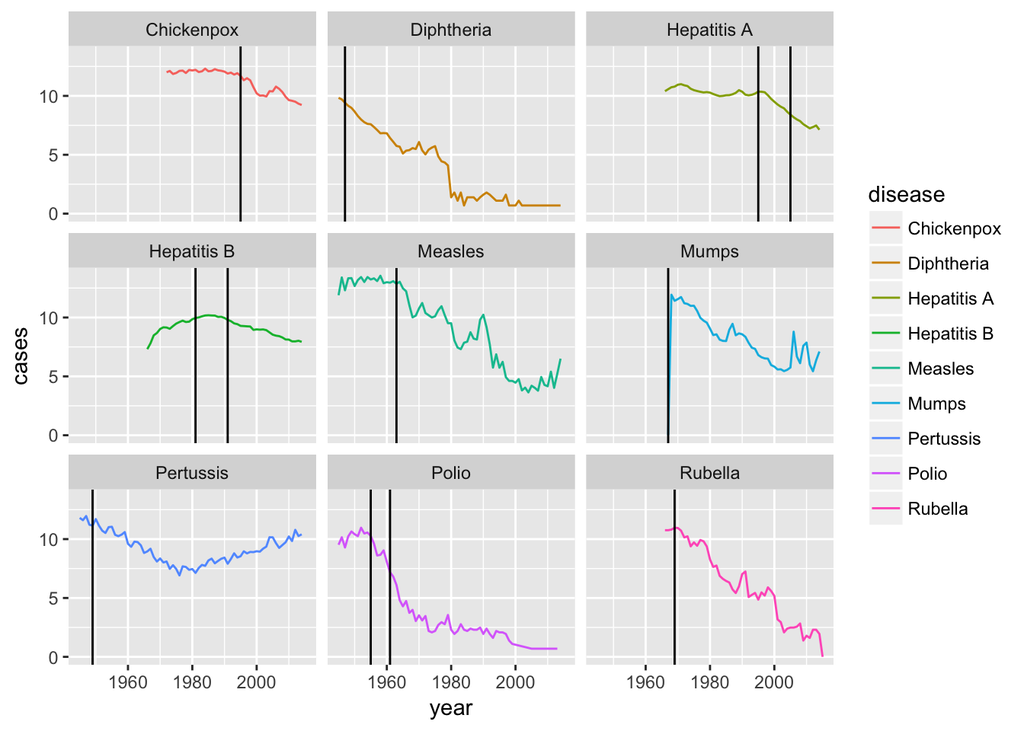

```r
library(readr)
library(ggplot2)
library(tidyverse)
aa<-read.csv('vaccine_data_online.csv')
bb<-(aa %>% mutate(cases =log(cases+1))
     %>% mutate(vaccine=if_else(vaccine==FALSE,FALSE,TRUE)) )
cc<- (bb %>% filter(vaccine==TRUE))
gg0<-ggplot(bb,aes(x=year,y=cases,colour=disease))
gg1<-gg0+geom_line()+facet_wrap(~disease)+geom_vline(data=cc,aes(xintercept = year))
gg1
```